# Ejercicio 1

En el circuito de la figura, la llave $S$ ha permanecido en la posición $1$ durante mucho tiempo. En el instante $t = 0$, la llave $S$ conmuta a la posición $2$. Calcular y graficar las corrientes $i_1$ e $i_2$ en función del tiempo.

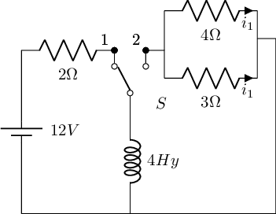

Cuando el enunciado dice que "la llave $S$ ha permanecido en la posición $1$ durante mucho tiempo" indica que esta parte del circuito está en régimen permanente, lo que implica que el inductor puede interpretarse como un cortocircuito para la fuente de corriente continua. Por lo tanto la corriente en este circuito es $I_0=\frac{12V}{2\Omega}=6A$.

Para $t=0$; cuando el interruptor cambia de la posición $1$ a la $2$; la inductancia tiene una carga inicial $I_0=6A$

El circuito para $t > 0$ es el siguiente:

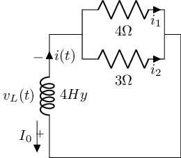

Ahora podemos plantear la ley de las tensiones de kirchhoff $v_L(t)+v_{R_{eq}}(t)=0$

y reemplazando por las relaciones Volt-Ampere correspondientes:

$\begin{equation}L \frac{di(t)}{dt}+ i(t)R=0\end{equation}$

Esto es una ecuación diferencial ordinaria de primer orden. La respuesta a estas ecuación diferencial tienen la forma:

$i(t)=Ae^{Dt}+B$ $(1)$

Aplicando el método del operador diferencial $D$ planteamos $(L . D .i+ Ri) = 0$ por lo que $D=-\frac{R}{L}$

Se define a $\tau=\frac{L}{R}$ como la constante de tiempo del circuito y es una medida de la duración de la respuesta transitoria

Para encontrar las constantes A y B se debe analizar el circuito en $t=0$ y $t=\infty$.

**Evaluación del circuito para $t=0$**

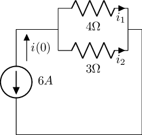

Inspeccionando el circuito obtenemos:

$i(0)=-6A$

Analizando la ecuación $(1)$ para $t=0$:

$A+B=-6A$

**Evaluación del circuito para $t=\infty$**

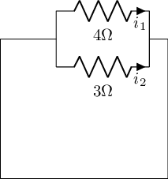

Inspeccionando el circuito obtenemos:

$i(\infty)=0$

Analizando la ecuación $(1)$ obtenemos:

$i(\infty)=B$

Por lo que podemos deducir que en este caso:

$B=0$

$A=-6A$

La solución por lo tanto será: $i(t)=-6e^{-0.428t}$

Ahora podremos calcular $i_1(t)$ e $i_2(t)$ aplicando la regla del divisor de corrientes.